# Poprawianie wykresu

Michał Matejczuk

# Oryginalny wykres

Poprawiano wykres przedstawiający zmiany w wydobyciu węgla kamiennego w Polsce w latach 2007-2022, który pojawił się w [artykule Bussines Insider z 25.10.2022](https://businessinsider.com.pl/gospodarka/ostry-spadek-wydobycia-wegla-kopalnie-wybraly-najgorszy-moment/rjy3sge).

[figure not shown]

# Poprawiony wykres

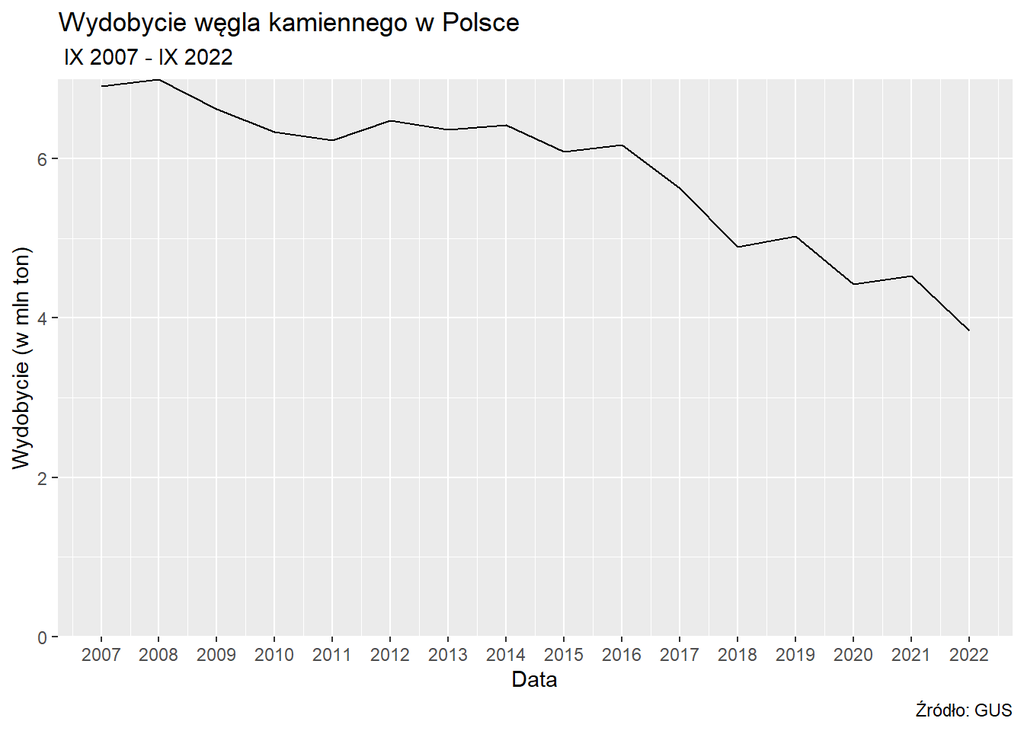

```r
library(dplyr)
library(ggplot2)
df <- data.frame(Year = c(2007, 2008, 2009, 2010, 2011, 2012, 2013, 2014, 2015, 2016, 2017, 2018, 2019, 2020, 2021, 2022),
                 Kilotons_of_charcoal = c(6913, 6992, 6624, 6337, 6234, 6479, 6367, 6425, 6086, 6172, 5633, 4888, 5025, 4427, 4532, 3842))

df %>% ggplot(aes(x = Year, y = Kilotons_of_charcoal/1000)) +
  geom_line() +
  scale_y_continuous(expand = c(0, 0), limits = c(0, NA))+
  scale_x_continuous(breaks = df$Year) +
  labs(title = "Wydobycie węgla kamiennego w Polsce",
       subtitle = " IX 2007 - IX 2022",
       caption ="Źródło: GUS",
       x = "Data",

       y = "Wydobycie (w mln ton)")
```

# Uzasadnienie

Największą wadą oryginalnego wykresu było niewątpliwie ułożenie czasu na osi x malejąco (od daty najpóźniejszej do najwcześniejszej). Sprawiało to wrażenie, że wydobycie węgla się zwiększa, podczas gdy celem wizualizacji było pokazanie spadku wydobycia. W poprawionym wykresie oś x została odwrócona w celu zwiększenia czytelności wykresu. Dodatkowo wartości wydobycia rozrzucone na krzywej zastąpiono obecnością osi y z wartościami wydobycia dzięki czemu wykres stał się mniej chaotyczny. Zmieniono też jednostkę wartości wydobycia z tys. ton na mln ton co pozwala na szybsze odczytanie wykresu (np. łatwiej przeczytać 6 mln ton niż 6000 tys. ton). Poprawiony wykres jest pozbawiony również poziomej linii na poziomie wartości z września 2022 gdyż tą samą rolę spełnia krata w tle wykresu. Odjęto również wypełnienie pod wykresem które mogło sugerować, że jest to wykres gęstości.

# Uwagi

Jak widać, kształty wykresów różnią się; jest to spowodowane uproszczeniem danych użytych do tworzenia poprawionego wykresu: mimo prób nie znaleziono danych źródłowych więc skorzystano z odczytów z oryginalnego wykresu jedynie dla września każdego roku. Nie zaburza to jednak ogólnej treści niesionej przez wykres.

Oryginalny wykres jest interaktywny więc ma przewagę możliwości odczytania dokładnej wartości dla każdego miesiąca w przedziale czasowym, uznano jednak że nie jest to kluczowe dla zrozumienia przesłania wykresu.